# Chapter 5 - Text Clustering and Topic Modeling

*Clustering documents using a wide variety of language models.*

This notebook is for Chapter 5 of the [Hands-On Large Language Models](https://www.amazon.com/Hands-Large-Language-Models-Understanding/dp/1098150961) book by [Jay Alammar](https://www.linkedin.com/in/jalammar) and [Maarten Grootendorst](https://www.linkedin.com/in/mgrootendorst/).

[figure not shown]

If you are viewing this notebook on Google Colab (or any other cloud vendor), you need to **uncomment and run** the following codeblock to install the dependencies for this chapter:

💡 **NOTE**: We will want to use a GPU to run the examples in this notebook. In Google Colab, go to **Runtime > Change runtime type > Hardware accelerator > GPU > GPU type > T4**.

```python
# %%capture
# !pip install bertopic datasets openai datamapplot
```

# **ArXiv Articles: Computation and Language**

```python
# Load data from huggingface
from datasets import load_dataset
dataset = load_dataset("maartengr/arxiv_nlp")["train"]

# Extract metadata
abstracts = dataset["Abstracts"]
titles = dataset["Titles"]
```

# **A Common Pipeline for Text Clustering**

## **1. Embedding Documents**

```python
from sentence_transformers import SentenceTransformer

# Create an embedding for each abstract
embedding_model = SentenceTransformer('thenlper/gte-small')
embeddings = embedding_model.encode(abstracts, show_progress_bar=True)
```

```python
# Check the dimensions of the resulting embeddings
embeddings.shape
```

```
(44949, 384)
```

## **2. Reducing the Dimensionality of Embeddings**

```python
from umap import UMAP

# We reduce the input embeddings from 384 dimenions to 5 dimenions
umap_model = UMAP(
    n_components=5, min_dist=0.0, metric='cosine', random_state=42
)
reduced_embeddings = umap_model.fit_transform(embeddings)
```

## **3. Cluster the Reduced Embeddings**

```python
from hdbscan import HDBSCAN

# We fit the model and extract the clusters
hdbscan_model = HDBSCAN(
    min_cluster_size=50, metric='euclidean', cluster_selection_method='eom'
).fit(reduced_embeddings)
clusters = hdbscan_model.labels_

# How many clusters did we generate?
len(set(clusters))
```

```
156
```

## **Inspecting the Clusters**

Manually inspect the first three documents in cluster 0:

```python
import numpy as np

# Print first three documents in cluster 0
cluster = 0
for index in np.where(clusters==cluster)[0][:3]:
    print(abstracts[index][:300] + "... \n")
```

```
  This works aims to design a statistical machine translation from English text
to American Sign Language (ASL). The system is based on Moses tool with some
modifications and the results are synthesized through a 3D avatar for
interpretation. First, we translate the input text to gloss, a written fo...

  Researches on signed languages still strongly dissociate lin- guistic issues
related on phonological and phonetic aspects, and gesture studies for
recognition and synthesis purposes. This paper focuses on the imbrication of
motion and meaning for the analysis, synthesis and evaluation of sign lang...

  Modern computational linguistic software cannot produce important aspects of
sign language translation. Using some researches we deduce that the majority of
automatic sign language translation systems ignore many aspects when they
generate animation; therefore the interpretation lost the truth inf...
```

Next, we reduce our embeddings to 2-dimensions so that we can plot them and get a rough understanding of the generated clusters.

```python
import pandas as pd

# Reduce 384-dimensional embeddings to 2 dimensions for easier visualization
reduced_embeddings = UMAP(
    n_components=2, min_dist=0.0, metric='cosine', random_state=42
).fit_transform(embeddings)

# Create dataframe
df = pd.DataFrame(reduced_embeddings, columns=["x", "y"])
df["title"] = titles
df["cluster"] = [str(c) for c in clusters]

# Select outliers and non-outliers (clusters)
clusters_df = df.loc[df.cluster != "-1", :]
outliers_df = df.loc[df.cluster == "-1", :]
```

### Static Plot

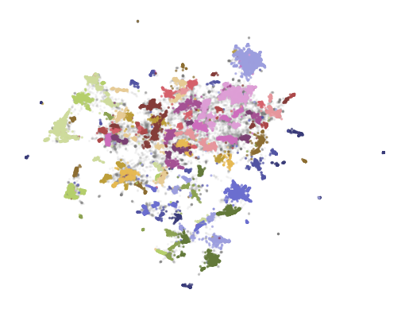

```python
import matplotlib.pyplot as plt

# Plot outliers and non-outliers seperately
plt.scatter(outliers_df.x, outliers_df.y, alpha=0.05, s=2, c="grey")
plt.scatter(
    clusters_df.x, clusters_df.y, c=clusters_df.cluster.astype(int),
    alpha=0.6, s=2, cmap='tab20b'
)
plt.axis('off')
# plt.savefig("matplotlib.png", dpi=300)  # Uncomment to save the graph as a .png
```

# From Text Clustering to Topic Modeling

## **BERTopic: A Modular Topic Modeling Framework**

```python
from bertopic import BERTopic

# Train our model with our previously defined models
topic_model = BERTopic(
    embedding_model=embedding_model,
    umap_model=umap_model,
    hdbscan_model=hdbscan_model,
    verbose=True
).fit(abstracts, embeddings)
```

```
2024-04-24 10:38:31,273 - BERTopic - Dimensionality - Fitting the dimensionality reduction algorithm
2024-04-24 10:39:22,540 - BERTopic - Dimensionality - Completed ✓
2024-04-24 10:39:22,543 - BERTopic - Cluster - Start clustering the reduced embeddings
2024-04-24 10:39:24,548 - BERTopic - Cluster - Completed ✓
2024-04-24 10:39:24,563 - BERTopic - Representation - Extracting topics from clusters using representation models.
2024-04-24 10:39:34,185 - BERTopic - Representation - Completed ✓
```

Now, let's start exploring the topics that we got by running the code above.

```python
topic_model.get_topic_info()
```

|  | Topic | Count | Name | Representation | Representative_Docs |
| --- | --- | --- | --- | --- | --- |
| 0 | -1 | 14520 | -1_the_of_and_to | [the, of, and, to, in, we, that, language, for... | [ This paper presents new state-of-the-art mo... |
| 1 | 0 | 2290 | 0_speech_asr_recognition_end | [speech, asr, recognition, end, acoustic, spea... | [ End-to-end models have achieved impressive ... |
| 2 | 1 | 1403 | 1_medical_clinical_biomedical_patient | [medical, clinical, biomedical, patient, healt... | [ Recent years have seen particular interest ... |
| 3 | 2 | 1156 | 2_sentiment_aspect_analysis_reviews | [sentiment, aspect, analysis, reviews, opinion... | [ Aspect-based sentiment analysis of review t... |
| 4 | 3 | 986 | 3_translation_nmt_machine_neural | [translation, nmt, machine, neural, bleu, engl... | [ Neural machine translation (NMT) becomes a ... |
| ... | ... | ... | ... | ... | ... |
| 151 | 150 | 54 | 150_coherence_discourse_paragraph_text | [coherence, discourse, paragraph, text, cohesi... | [ While there has been significant progress t... |
| 152 | 151 | 54 | 151_prompt_prompts_optimization_prompting | [prompt, prompts, optimization, prompting, llm... | [ Prompt optimization aims to find the best p... |
| 153 | 152 | 53 | 152_sentence_sts_embeddings_similarity | [sentence, sts, embeddings, similarity, embedd... | [ Sentence representation at the semantic lev... |
| 154 | 153 | 53 | 153_counseling_mental_health_therapy | [counseling, mental, health, therapy, psychoth... | [ Mental health care poses an increasingly se... |
| 155 | 154 | 50 | 154_backdoor_attacks_attack_triggers | [backdoor, attacks, attack, triggers, poisoned... | [ Deep neural networks (DNNs) and natural lan... |

156 rows × 5 columns

```python
topic_model.get_topic(0)
```

```
[('speech', 0.028177697715245358),
 ('asr', 0.018971184497453525),
 ('recognition', 0.013457745472471012),
 ('end', 0.00980445092749381),
 ('acoustic', 0.009452082794507863),
 ('speaker', 0.0068822647060204885),
 ('audio', 0.006807649923681604),
 ('the', 0.0063343444687017645),
 ('error', 0.006320144717019838),
 ('automatic', 0.006290216996043161)]
```

We can use the `find_topics()` function to search for specific topics based on a search term. Let’s search for a topic about topic modeling:

```python
topic_model.find_topics("topic modeling")
```

```
([22, -1, 1, 47, 32],
 [0.95456535, 0.91173744, 0.9074769, 0.9067007, 0.90510106])
```

It returns that topic 22 has a relatively high similarity (0.95) with our search term. If we then inspect the topic, we can see that it is indeed a topic about topic modeling:

```python
topic_model.get_topic(22)
```

```
[('topic', 0.06634619076655907),
 ('topics', 0.035308535091932707),
 ('lda', 0.016386314730705634),
 ('latent', 0.013372311924864435),
 ('document', 0.012973600191120576),
 ('documents', 0.012383715497143821),
 ('modeling', 0.011978375291037142),
 ('dirichlet', 0.010078277589545706),
 ('word', 0.008505619415413312),
 ('allocation', 0.007930890698168108)]
```

That seems like a topic that is, in part, characterized by the classic LDA technique. Let's see if the BERTopic paper was also assigned to topic 22:

```python
topic_model.topics_[titles.index('BERTopic: Neural topic modeling with a class-based TF-IDF procedure')]
```

```
22
```

### **Visualizations**

**Visualize Documents**

```python
# Visualize topics and documents
fig = topic_model.visualize_documents(
    titles,
    reduced_embeddings=reduced_embeddings,
    width=1200,
    hide_annotations=True
)

# Update fonts of legend for easier visualization
fig.update_layout(font=dict(size=16))
```

```
Output hidden; open in https://colab.research.google.com to view.
```

```python
# Visualize barchart with ranked keywords
topic_model.visualize_barchart()

# Visualize relationships between topics
topic_model.visualize_heatmap(n_clusters=30)

# Visualize the potential hierarchical structure of topics
topic_model.visualize_hierarchy()
```

[interactive chart not shown]

## **Representation Models**

In these examples that follow, we will update our topic representations **after** having trained our model. This allows for quick iteration. If, however, you want to use a representation model at the start of training, you will need to run it as follows:

```
from bertopic.representation import KeyBERTInspired
from bertopic import BERTopic

# Create your representation model
representation_model = KeyBERTInspired()

# Use the representation model in BERTopic on top of the default pipeline
topic_model = BERTopic(representation_model=representation_model)
```

To use the representation models, we are first going to duplicate our topic model such that easily show the differences between a model with and without representation model.

```python
# Save original representations
from copy import deepcopy
original_topics = deepcopy(topic_model.topic_representations_)
```

```python
def topic_differences(model, original_topics, nr_topics=5):
    """Show the differences in topic representations between two models """
    df = pd.DataFrame(columns=["Topic", "Original", "Updated"])
    for topic in range(nr_topics):

        # Extract top 5 words per topic per model
        og_words = " | ".join(list(zip(*original_topics[topic]))[0][:5])
        new_words = " | ".join(list(zip(*model.get_topic(topic)))[0][:5])
        df.loc[len(df)] = [topic, og_words, new_words]

    return df
```

### KeyBERTInspired

```python
from bertopic.representation import KeyBERTInspired

# Update our topic representations using KeyBERTInspired
representation_model = KeyBERTInspired()
topic_model.update_topics(abstracts, representation_model=representation_model)

# Show topic differences
topic_differences(topic_model, original_topics)
```

|  | Topic | Original | Updated |
| --- | --- | --- | --- |
| 0 | 0 | speech \| asr \| recognition \| end \| acoustic | speech \| encoder \| phonetic \| language \| trans... |
| 1 | 1 | medical \| clinical \| biomedical \| patient \| he... | nlp \| ehr \| clinical \| biomedical \| language |
| 2 | 2 | sentiment \| aspect \| analysis \| reviews \| opinion | aspect \| sentiment \| aspects \| sentiments \| cl... |
| 3 | 3 | translation \| nmt \| machine \| neural \| bleu | translation \| translating \| translate \| transl... |
| 4 | 4 | summarization \| summaries \| summary \| abstract... | summarization \| summarizers \| summaries \| summ... |

### Maximal Marginal Relevance

```python
from bertopic.representation import MaximalMarginalRelevance

# Update our topic representations to MaximalMarginalRelevance
representation_model = MaximalMarginalRelevance(diversity=0.5)
topic_model.update_topics(abstracts, representation_model=representation_model)

# Show topic differences
topic_differences(topic_model, original_topics)
```

|  | Topic | Original | Updated |
| --- | --- | --- | --- |
| 0 | 0 | speech \| asr \| recognition \| end \| acoustic | speech \| asr \| error \| model \| training |
| 1 | 1 | medical \| clinical \| biomedical \| patient \| he... | clinical \| biomedical \| patient \| healthcare \|... |
| 2 | 2 | sentiment \| aspect \| analysis \| reviews \| opinion | sentiment \| analysis \| reviews \| absa \| polarity |
| 3 | 3 | translation \| nmt \| machine \| neural \| bleu | translation \| nmt \| bleu \| parallel \| multilin... |
| 4 | 4 | summarization \| summaries \| summary \| abstract... | summarization \| document \| extractive \| rouge ... |

## Text Generation

### Flan-T5

```python
from transformers import pipeline
from bertopic.representation import TextGeneration

prompt = """I have a topic that contains the following documents:
[DOCUMENTS]

The topic is described by the following keywords: '[KEYWORDS]'.

Based on the documents and keywords, what is this topic about?"""

# Update our topic representations using Flan-T5
generator = pipeline('text2text-generation', model='google/flan-t5-small')
representation_model = TextGeneration(
    generator, prompt=prompt, doc_length=50, tokenizer="whitespace"
)
topic_model.update_topics(abstracts, representation_model=representation_model)

# Show topic differences
topic_differences(topic_model, original_topics)
```

|  | Topic | Original | Updated |
| --- | --- | --- | --- |
| 0 | 0 | speech \| asr \| recognition \| end \| acoustic | Speech-to-description \| \| \| \| |
| 1 | 1 | medical \| clinical \| biomedical \| patient \| he... | Science/Tech \| \| \| \| |
| 2 | 2 | sentiment \| aspect \| analysis \| reviews \| opinion | Review \| \| \| \| |
| 3 | 3 | translation \| nmt \| machine \| neural \| bleu | Attention-based neural machine translation \| ... |
| 4 | 4 | summarization \| summaries \| summary \| abstract... | Summarization \| \| \| \| |

### OpenAI

```python
import openai
from bertopic.representation import OpenAI

prompt = """
I have a topic that contains the following documents:
[DOCUMENTS]

The topic is described by the following keywords: [KEYWORDS]

Based on the information above, extract a short topic label in the following format:
topic: <short topic label>
"""

# Update our topic representations using GPT-3.5
client = openai.OpenAI(api_key="YOUR_KEY_HERE")
representation_model = OpenAI(
    client, model="gpt-3.5-turbo", exponential_backoff=True, chat=True, prompt=prompt
)
topic_model.update_topics(abstracts, representation_model=representation_model)

# Show topic differences
topic_differences(topic_model, original_topics)
```

|  | Topic | Original | Updated |
| --- | --- | --- | --- |
| 0 | 0 | speech \| asr \| recognition \| end \| acoustic | Leveraging External Data for Improving Low-Res... |
| 1 | 1 | medical \| clinical \| biomedical \| patient \| he... | Improved Representation Learning for Biomedica... |
| 2 | 2 | sentiment \| aspect \| analysis \| reviews \| opinion | "Advancements in Aspect-Based Sentiment Analys... |
| 3 | 3 | translation \| nmt \| machine \| neural \| bleu | Neural Machine Translation Enhancements |
| 4 | 4 | summarization \| summaries \| summary \| abstract... | Document Summarization Techniques |

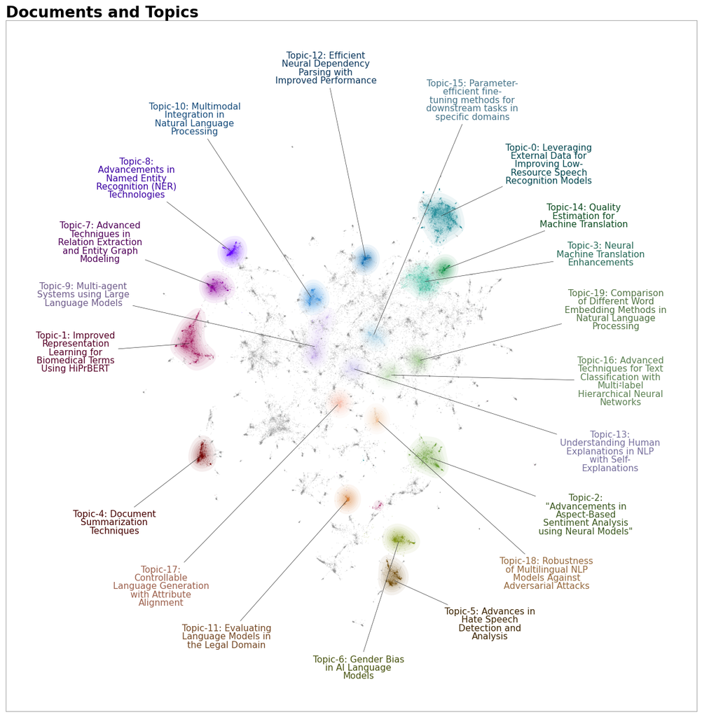

```python
# Visualize topics and documents
fig = topic_model.visualize_document_datamap(
    titles,
    topics=list(range(20)),
    reduced_embeddings=reduced_embeddings,
    width=1200,
    label_font_size=11,
    label_wrap_width=20,
    use_medoids=True,
)
plt.savefig("datamapplot.png", dpi=300)
```

## **BONUS**: Word Cloud

Make sure to pip install `wordcloud` first in order to follow this bonus:

First, we need to make sure that each topic is described by a bit more words than just 10 as that would make for a much more interesting wordcloud.

```python
topic_model.update_topics(abstracts, top_n_words=500)
```

[figure not shown]

```python
from wordcloud import WordCloud
import matplotlib.pyplot as plt

def create_wordcloud(model, topic):
    plt.figure(figsize=(10,5))
    text = {word: value for word, value in model.get_topic(topic)}
    wc = WordCloud(background_color="white", max_words=1000, width=1600, height=800)
    wc.generate_from_frequencies(text)
    plt.imshow(wc, interpolation="bilinear")
    plt.axis("off")
    plt.show()

# Show wordcloud
create_wordcloud(topic_model, topic=17)
```